# COVID-19 Regional Models for Colorado

09/22/2021

**Prepared by the Colorado COVID-19 Modeling Group**  
Colorado School of Public Health: Elizabeth Carlton, Debashis Ghosh, Irina Kasarskis, Talia Quandelacy, Jonathan Samet; University of Colorado-Boulder Department of Applied Mathematics: Sabina Altus, David Bortz; Colorado State University: Jude Bayham; University of Maryland School of Medicine: Andrea Buchwald

For Contact: Jon.Samet@CUAnschutz.edu

### **Introduction**

This report provides the results of epidemic models for regions of Colorado, using methods similar to that used for the state-level model. Estimates are presented for the 11 Local Public Health Agencies (LPHAs) regions in the state and for 8 selected counties with populations that are sufficiently large to allow for county-level estimates. The model results are subject to greater uncertainty than those for the entire state because there are fewer hospitalizations and cases in each region than in the state as a whole. Estimates are most uncertain for the regions with the smallest population size. We use the model as well as COVID-19 hospital,and vaccination data to generate four measures for each region. These measures can be used to gauge the current state of SARS-CoV-2 in each region.

- *The effective reproduction number (Re)* is a measure of how rapidly infections are spreading or declining in a region.
- *Infection prevalence* is an estimate of the portion of the population currently infected and capable of spreading infections. It can be used to gauge how risky contacts are.
- *The percent of the population fully vaccinated to date* is based on data provided by CDPHE and includes all people who have received one dose of Johnson and Johnson or two doses of Pfizer or Moderna vaccine. Because it takes approximately a month to develop immunity, some of these individuals may not yet be immune to the virus.
- *The percent of population estimated to be immune* is estimated from the number of individuals immune due to vaccination combined with the individuals immune due to infection. These estimates account for the time between vaccination and immunity and the efficacy of the vaccine. As the immune population grows, due to vaccination or prior infection, the spread of infection slows.

**Table 1.** The estimated effective reproductive number, prevalence of infections, percent of the population immune and vaccinated to date by region. These metrics are estimated using hospitalization data from the Colorado COVID Patient Hospitalization Surveillance (COPHS). Effective reproductive number (Re) reflects hospitalization data through 09/13/2021. The prevalence of infections and percent of the population immune is estimated for 09/06/2021. The percent vaccinated estimates are based on data provided by CDPHE through 09/19/2021 and reflect the proportion of the population that is fully vaccinated as of that date.

|  | Are infections increasing or decreasing? Re | Are infections increasing or decreasing? Infections are… | How many people are infectious? Prevalence per 100,000 | How many people are infectious? People infectious | Percent of Population Estimated Immune | Percent of Population Fully Vaccinated |
| --- | --- | --- | --- | --- | --- | --- |
| **LPHA Regions** |  |  |  |  |  |  |
| Central | 1.0 | Flat | 1,464 | 1 in 68 | 69.9 | 50.9 |
| Central Mountains | 1.1 | Increasing | 513 | 1 in 195 | 65.4 | 63.6 |
| East Central | 0.6 | Decreasing | 3,050 | 1 in 33 | 75.0 | 36.2 |
| Metro | 0.9 | Decreasing | 851 | 1 in 117 | 72.7 | 62.3 |
| Northeast | 0.9 | Decreasing | 1,745 | 1 in 57 | 71.3 | 51.7 |
| Northwest | 1.1 | Increasing | 1,179 | 1 in 85 | 67.5 | 44.9 |
| San Luis Valley | 1.1 | Increasing | 549 | 1 in 182 | 58.7 | 46.2 |
| South Central | 1.0 | Flat | 1,890 | 1 in 53 | 73.9 | 45.0 |
| Southeast | 1.8 | Increasing | 1,118 | 1 in 89 | 55.7 | 34.6 |
| Southwest | 0.6 | Decreasing | 583 | 1 in 171 | 66.3 | 56.2 |
| West Central Partnership | 1.0 | Flat | 673 | 1 in 149 | 57.2 | 48.2 |
| **Eight select counties** |  |  |  |  |  |  |
| Adams | 0.9 | Decreasing | 1,047 | 1 in 95 | 80.0 | 55.8 |
| Arapahoe | 0.7 | Decreasing | 949 | 1 in 105 | 73.9 | 59.4 |
| Boulder | 1.1 | Increasing | 732 | 1 in 137 | 71.2 | 68.6 |
| Broomfield | 0.1 | Decreasing | 133 | 1 in 752 | 67.1 | 68.3 |
| Denver | 1.0 | Flat | 688 | 1 in 145 | 78.1 | 64.8 |
| Douglas | 0.8 | Decreasing | 691 | 1 in 145 | 65.6 | 61.1 |
| El Paso | 1.0 | Flat | 1,685 | 1 in 59 | 72.8 | 51.1 |
| Jefferson plus | 1.1 | Increasing | 552 | 1 in 181 | 66.7 | 64.7 |

Due to the small population sizes of Gilpin and Clear Creek counties, these counties are combined with Jefferson County. Jefferson County comprises 97% of the population in the Jefferson plus county cluster.  
Due to lags between infection and hospitalization, the estimated effective reproductive number (Re) reflects the spread of infections approximately two weeks prior to the data of the last observed hospitalization.  
Immunity from vaccination is based on assumptions that the Moderna and Pfizer vaccines are 52% effective after 14 days and 90% effective a week after the second dose; the Johnson and Johnson vaccine is assumed to be 72% effective 28 days after the first dose. In the model, it is assumed that immunity due to infection wanes after 6 months if an individual has an asymptomatic infection, 12 months if symptomatic. Age distribution of vaccination by region is inferred from state-level age distribution data.

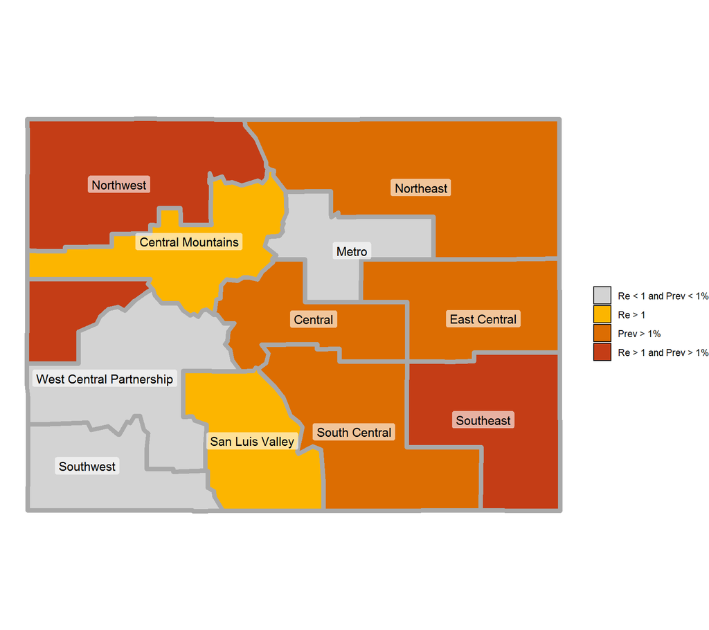

**Figure 1.** Map showing the 11 LPHA regions for which estimates were generated. Regions in yellow (effective reproductive number > 1), orange (prevalence > 1%), or red (both effective reproductive number > 1 and prevalence > 1%) indicate areas of concern.

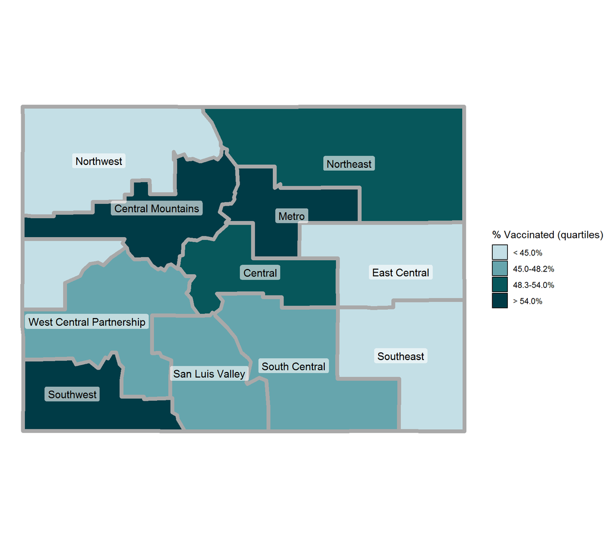

**Figure 2.** Map showing the percent of the population fully vaccinated by LPHA region. Estimates are based on data provided by CDPHE through 09/19/2021 and reflect the proportion of the population that has received one dose of Johnson and Johnson or two doses of Pfizer or Moderna vaccines as of that date. Darker colors indicate a higher proportion of vaccinated residents.

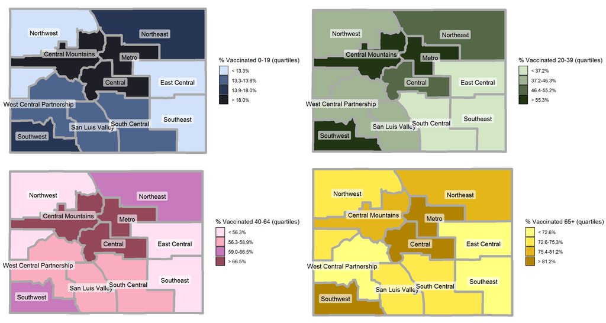

**Figure 3.** Map showing the percent of the population fully vaccinated by age group and LPHA region. Estimates are based on data provided by CDPHE through 09/19/2021 and reflect the proportion of the population that has received one dose of Johnson and Johnson or two doses of Pfizer or Moderna vaccines as of that date. Darker colors indicate a higher proportion of vaccinated residents.

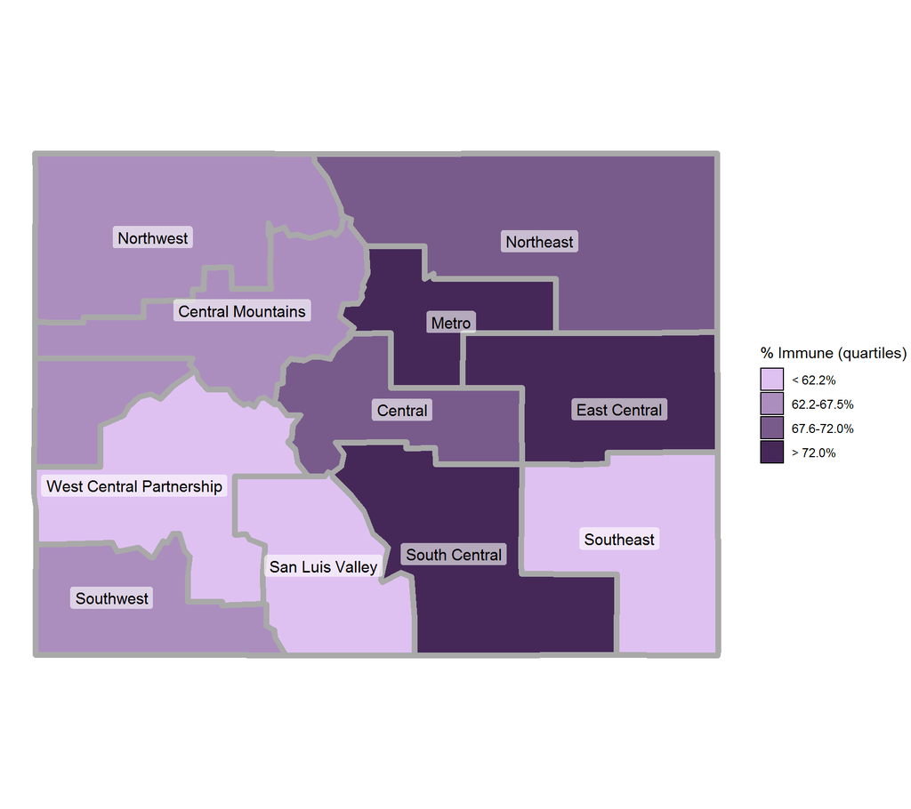

### **Effective Reproductive Number**

The figure below shows the estimated effective reproductive number for each region since March.

The effective reproduction number (Re) is a measure of how rapidly infections are spreading or declining in a region at a given point in time. When the effective reproductive number is below 1, infections are decreasing. When the effective reproductive number is above 1, infections are increasing.

The effective reproductive number is estimated using our age-structured meta-population model fit to hospitalization data. Because we base our parameter estimates primarily on COVID-19 hospitalization data, and hospitalizations today generally reflect infections occurring approximately 13 days prior, our most recent estimates of the effective reproductive number likely reflect the spread of infections occurring on approximately 08/31/2021.

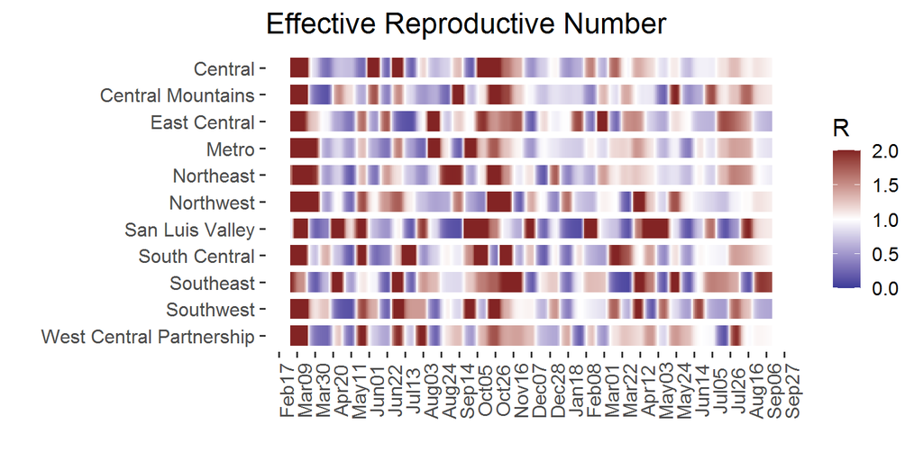

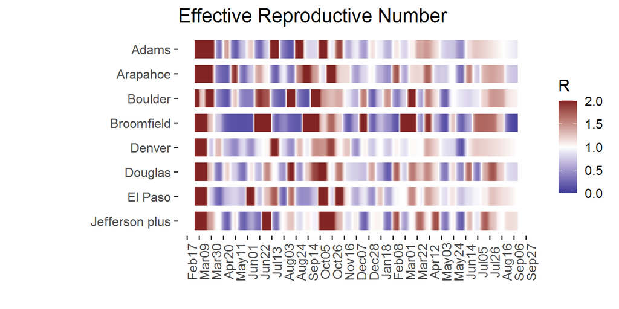

**Figure 5.** Estimated effective reproductive number (Re) over time in the 11 LPHA regions in Colorado, and 8 selected counties and county clusters. Estimates shown using COVID-19 hospitalization data through 09/13/2021.

### **Infection prevalence**

Infection prevalence provides an estimate of the proportion of the population that is currently infected with SARS-CoV-2 and capable of spreading infections. At higher levels of infection prevalence, individuals are more likely to encounter infectious individuals among their contacts. Because many people experience no symptoms or mild symptoms of COVID-19, many infections are not identified by surveillance systems. The estimates we present here are intended to provide an approximation of all infections, including those not detected by the Colorado Electronic Disease Reporting System (CEDRS).

The figure below shows the estimated infection prevalence per 100,000 individuals for each region. These are estimated from the age-structured meta-population model.

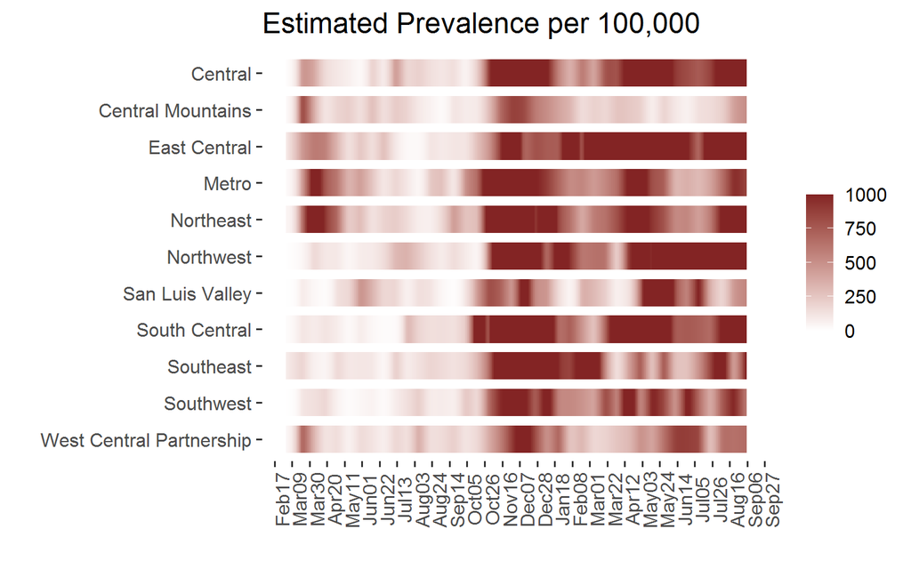

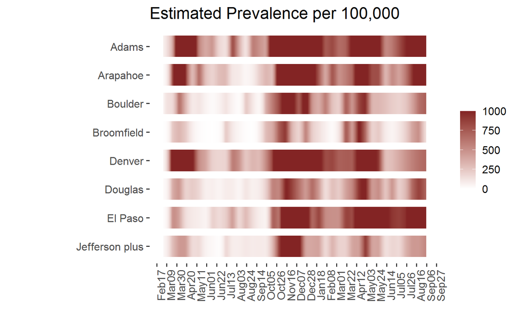

**Figure 6.** Estimated prevalence per 100,000 population for each of the 11 LPHA regions (top), plus the 8 selected counties and county clusters (bottom). All prevalence values over 1,000 per 100,000 are shown in dark red. Prevalence values estimated up to 09/06/2021.

### **COVID-19 hospitalizations**

The figures below show the daily number of individuals hospitalized with COVID-19 from each region. Hospitalization data are from the COVID Patient Hospitalization Surveillance (COPHS) maintained by the Colorado Department of Public Health and the Environment (CDPHE). Each COVID-19 patient is assigned to a region based on their home zip code. COVID-19 hospitalizations are shown per 100,000 population to allow comparability across regions.

COVID-19 hospitalizations are a sensitive measure of SARS-CoV-2 transmission and are an important indicator of the severity of infections in a region. While many SARS-CoV-2 infections are not captured by state surveillance systems, we expect that almost all COVID-19 hospitalizations are identified.

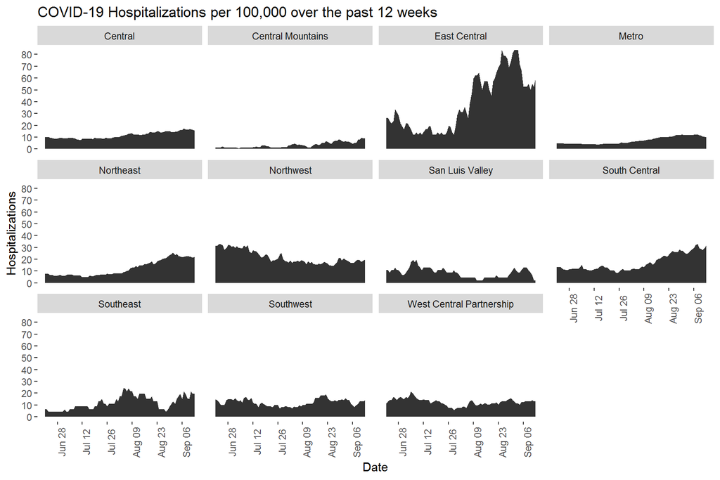

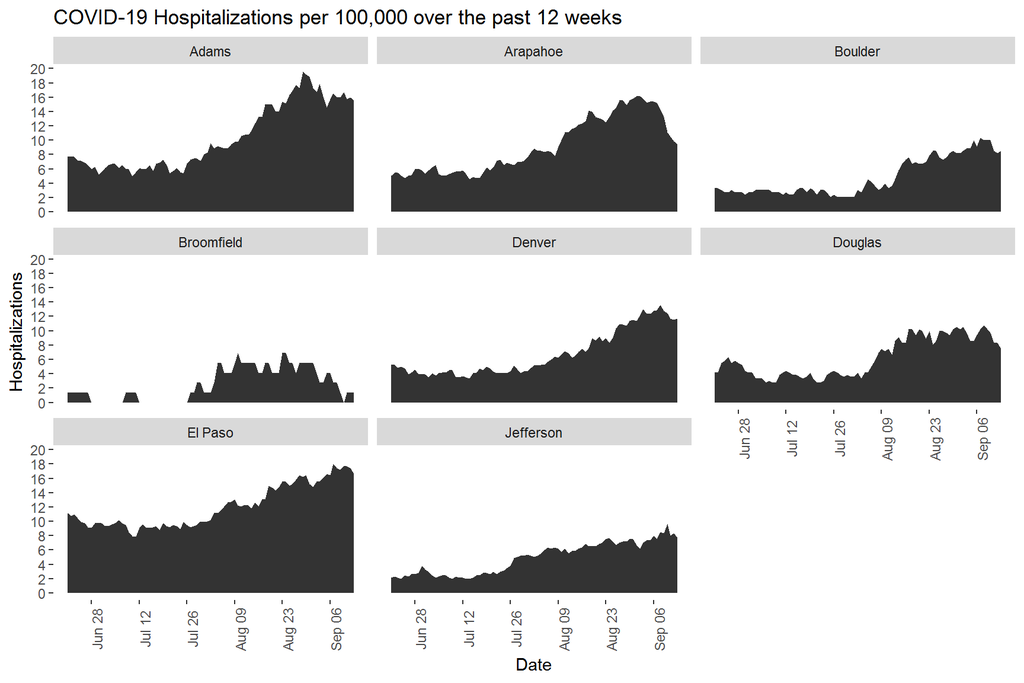

**Figure 7.** The daily number of people hospitalized with COVID-19 per capita for the 11 LPHA regions and the 8 selected counties and county clusters in Colorado over the past 12 weeks. Hospitalization data are from the COPHS hospital census data through 09/13/2021.

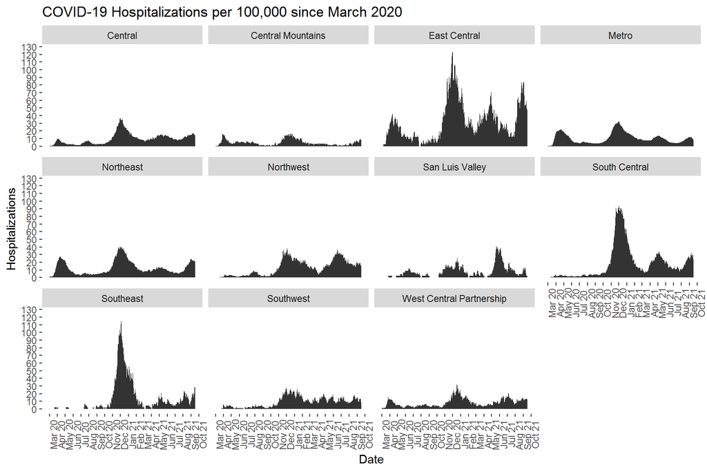

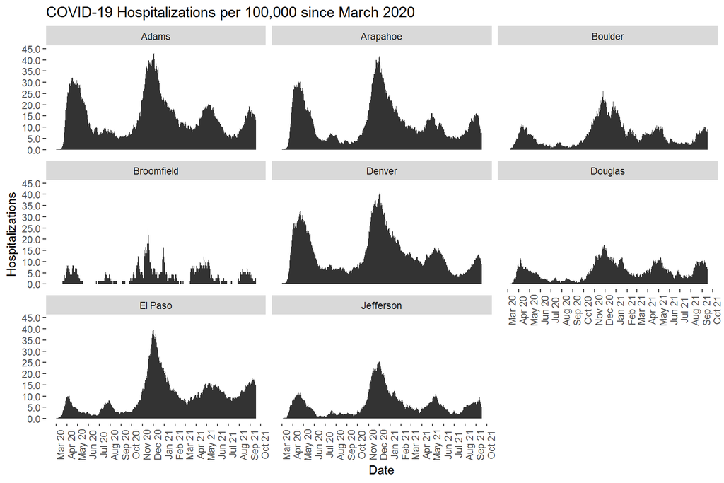

**Figure 8.** The daily number of people hospitalized with COVID-19 hospitalizations per capita for the 11 LPHA regions and the 8 selected counties and county clusters in Colorado since the first case was reported in March 2020. Hospitalization data are from the COPHS hospital census data through 09/13/2021.

### **Technical Summary**

Within the State of Colorado, as for other states, the spread of SARS-CoV-2 varies across the regions of the state, differing between urban and rural locations and resort and non-resort areas, for example. The modeling carried out by the Colorado COVID-19 Modeling Group was initiated at the state level providing a picture that does not give detail at the regional or county-level. Such detail is needed for public health planning and action.

To provide the needed detail, the Modeling Group developed regional-level models, using approaches similar to those for the overall Colorado model. To date, we have used scaled-down versions of the state-wide SEIR model to generate estimates of the effective reproductive number, infection prevalence, and the cumulative number of people infected in the 11 LPHA regions and 8 select counties with larger population size.

**Model updates this week.** The model has been updated to account for the presence of variants of concern in Colorado that may increase the rate of hospitalization. In the model, we now include the assumptions that that the Alpha (B.1.1.7) and Delta COVID-19 variants increase the rate at which symptomatic individuals are hospitalized by 40 and 70 percent, respectively, consistent with the state-level model and based on scientific evidence to date. These updates impact our estimates of disease prevalence regionally. Though we do not expect that variant strains spread uniformly across the state, an alternative cannot be verified with the available data, and thus we assume that the regional proportion of each variant matches the statewide distribution as described by CDPHE. To implement these changes, the original hospitalization rate is scaled by the sum of the relative rate increases, weighted by the proportion of the corresponding variant in the population, that is, hospitalization_rate_with_variants = original_hospitalization_rate x [1 x percent_of_wild_type_cases + 1.4 x percent_of_Alpha_cases + 1.7 x percent_of_Delta_cases]. While the proportion of each variant changes continuously, we approximate the necessary scaling factor over three time intervals corresponding to (1) the arrival of variants, (2) Alpha dominance, and (3) Delta dominance, shown in the plot below.

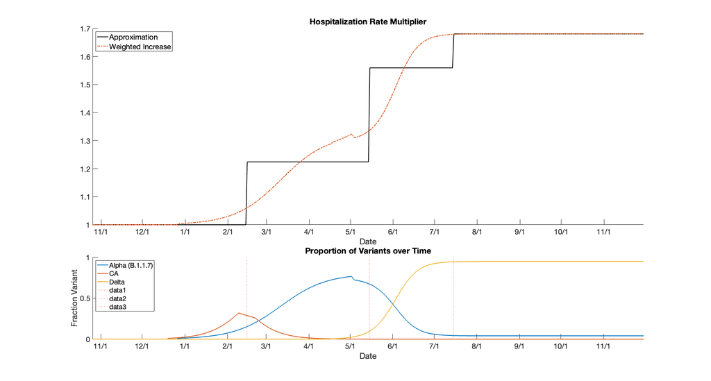

**Methods.** We use data on COVID-19 hospitalizations, mobile-phone based mobility data and an age-structured meta-population model of SARS-CoV-2 transmission to estimate the current state of infections in each region. The model is similar in many ways to the state-wide model, in that it accounts for differences in the severity of infection by age and uses Colorado-specific demographic and clinical data. For example, the length of time a COVID-19 patient spends in the hospital varies by age and is based on data provided by Colorado hospitals. A full description of the model and estimation approaches are provided in the documentation, available [here](https://agb85.github.io/covid-19/SEIR%20Documentation.pdf). Prior modeling reports and documentation can be found [here](https://agb85.github.io/covid-19/).

**Data Sources:** COVID-19 hospitalizations are obtained from COPHS reported through 09/17/2021.Due to lags in reporting, these data are cleaved 4 days prior such that hospitalizations through 09/13/2021 are used in modeling and shown in this report. A new case definition for COVID-19 hospitalizations was introduced on August 13, 2021 and was applied retroactively to all previously reported hospitalizations. Patients admitted or under observation status for 24 hours or more and meet one of the following criteria: admission diagnosis of COVID-19, discharge diagnosis of COVID-19, or received positive COVID-19 diagnostic test (antigen, rapid molecular, or PCR) during the hospitalization are reported to COPHS as a COVID-19 hospitalization. SARS-CoV-2 vaccination data by county are provided by CDPHE weekly. Age distribution of vaccination by region is inferred from state-level age distribution data.

Case data are based on CEDRS through 09/18/2021. Due to lags in reporting, these data are cleaved ten days prior on 09/08/2021. These data sources are provided by CDPHE.

Population movement between regions is estimated from weekly aggregated cell-phone data, provided by xmode, through 09/12/2021.

**Limitations:** The regional model estimates are subject to greater uncertainty than those for the entire state because there are fewer hospitalizations in each region than in the state as a whole. Estimates are most uncertain for the regions with the smallest population size. This model uses real-time mobility to account for the flow of populations between regions. It remains an open question in the scientific community how to use measures of population movement to accurately model the spread of infections

| Region | Population | Counties |
| --- | --- | --- |
| **LPHA Regions** |  |  |
| Central | 801,025 | Chaffee, El Paso, Lake, Park, Teller |
| Central Mountains | 179,767 | Eagle, Garfield, Grand, Pitkin, Summit |
| East Central | 41,837 | Cheyenne, Elbert, Kit Carson, Lincoln |
| Metro | 3,274,440 | Adams, Arapahoe, Boulder, Broomfield, Clear Creek, Denver, Douglas, Gilpin, Jefferson* |
| Northeast | 764,381 | Larimer, Logan, Morgan, Phillips, Sedgwick, Washington, Weld, Yuma |
| Northwest | 202,304 | Jackson, Mesa, Moffat, Rio Blanco, Routt |
| San Luis Valley | 45,988 | Alamosa, Conejos, Costilla, Rio Grande, Saguache |
| South Central | 242,903 | Custer, Fremont, Huerfano, Las Animas, Pueblo |
| Southeast | 46,073 | Baca, Bent, Crowley, Kiowa, Otero, Prowers |
| Southwest | 100,155 | Archuleta, Dolores, La Plata, Montezuma, San Juan |
| West Central Partnership | 106,628 | Delta, Gunnison, Hinsdale, Mineral, Montrose, Ouray, San Miguel |
| **Eight select counties** |  |  |
| Adams | 520,268 | Adams |
| Arapahoe | 656,618 | Arapahoe |
| Boulder | 328,562 | Boulder |
| Broomfield | 72,481 | Broomfield |
| Denver | 736,522 | Denver |
| Douglas | 360,940 | Douglas |
| El Paso | 728,076 | El Paso |
| Jefferson plus | 599,049 | Clear Creek, Gilpin, Jefferson |

**Table 2:** Description of the regions used in this report, including the 11 LPHA Regions. Population estimates are based on 2020 US Census Projections provided by the Colorado Demography Office.

*Clear Creek, Gilpin Counties and Jefferson counties are modeled as a single unit due to the small population of Clear Creek (9,379 residents) and Gilpin (5,924 residents) – populations too small to allow for stable estimation.

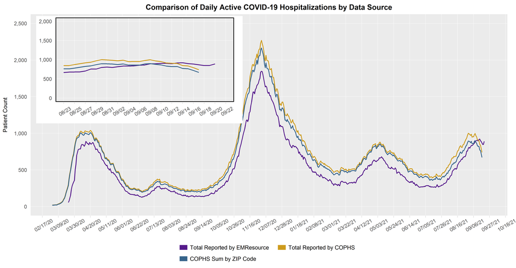

**Figure 9.** Comparison of daily active COVID-19 hospitalizations by data source.